# Produção de Material Didático e de Divulgação · Cartilhas, Folders, Vídeos e Mídias para Extensão Rural

Extensão Rural

Prof. Dr. Luiz Diego Vidal Santos

## Abertura Visão Geral da Aula

Roteiro da aula Tópicos estruturantes

- 1 O Material Didático na ATER
- 2 Princípios de Comunicação para o Campo
- 3 Cartilhas e Publicações Técnicas
- 4 Folders, Panfletos e Banners
- 5 Produção Audiovisual (Vídeo e Rádio)
- 6 Mídias Digitais e ATER Digital

Objetivo central Comunicação técnica acessível

Desenvolver competências para a produção de material didático e de divulgação voltado à extensão rural, abordando princípios de comunicação, formatos, linguagem adequada ao público-alvo e ferramentas acessíveis para cartilhas, folders, vídeos e conteúdos digitais.

Cartilhas & Folders Vídeo, Rádio & Podcast ATER Digital · WhatsApp

Traduzir conhecimento técnico em materiais dialógicos, legíveis e validados com os agricultores.

# Fundamentos e Comunicação Rural

## Fundamentos O Material Didático na ATER

01 · Multiplicação Alcance permanente · Coelho (2014)

Amplia a orientação técnica para além do encontro presencial, servindo de referência permanente e instrumento de multiplicação comunitária.

02 · Previsão Legal PNATER (Lei 12.188/2010)

Prevê a produção de materiais educativos para a agricultura familiar; Chamadas Públicas de ATER exigem cartilhas, folders e vídeos como produtos (Brasil, 2010).

03 · Tradução Dialógica Papel do extensionista

Não é tarefa secundária ou estética: exige traduzir ciência em linguagem acessível, selecionar o suporte certo e co-produzir com os agricultores.

Material didático eficaz nasce da **escuta do território** e retorna ao campo como apoio prático à autonomia do agricultor.

## Ciclo Fluxo de Produção: Do Campo ao Campo

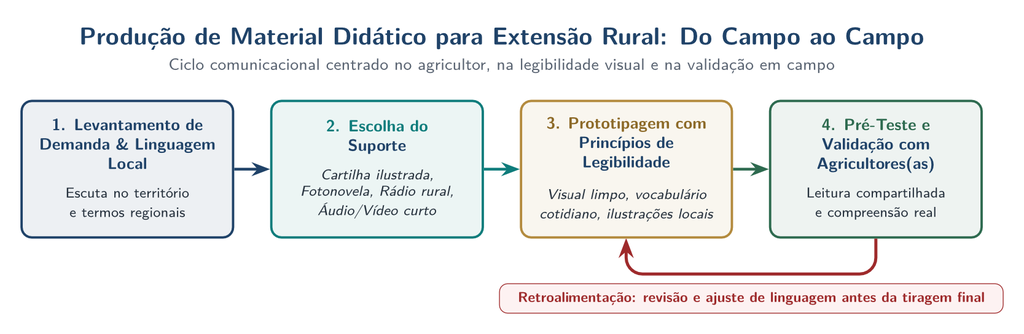

Ciclo comunicacional em quatro etapas com retroalimentação para produção de material didático em extensão rural.

Produção de Material Didático para Extensão Rural: Do Campo ao Campo 1. Levantamento de Demanda & Linguagem Local → 2. Escolha do Suporte → 3. Prototipagem com Legibilidade → 4. Pré-Teste e Validação (com retroalimentação)

## Comunicação Princípios de Comunicação para o Campo

Freire (1983) Comunicação dialógica

A extensão como mera transmissão viola a condição de sujeito do agricultor. O material didático deve ser **dialógico**, nunca prescritivo.

Bordenave (1983) Aderência à realidade

A mensagem eficaz parte da realidade do receptor, adota seu vocabulário, respeita seus valores culturais e traz soluções aplicáveis ao concreto.

**1.** Partir da realidade e do vocabulário local do público

**2.** Priorizar informação prática e diretamente aplicável

**3.** Utilizar exemplos locais e sistemas reconhecíveis

**4.** Respeitar diversidades culturais e níveis de escolaridade

**5.** Privilegiar imagem sobre texto quando há baixa escolaridade

**6.** Permitir que o agricultor se veja representado no material

# Impressos e Design Visual

## Impressos Cartilhas e Publicações Técnicas

**Formato clássico da ATER:** publicação impressa e digital (geralmente de **16 a 48 páginas**) que desenvolve de modo didático um tema técnico orientado à prática. A **Embrapa (2023)** mantém amplo acervo gratuito de referência.

Anatomia editorial Estrutura de uma Cartilha

1. **Capa:** identifica tema, autoria e instituição
2. **Apresentação:** contextualiza problema e público-alvo
3. **Corpo técnico:** ilustrações, fotos e esquemas acessíveis
4. **Seção prática:** orientações passo a passo aplicáveis
5. **Fechamento:** referências e contatos da equipe de ATER

Clareza e identificação Boas Práticas de Redação

- Frases e parágrafos curtos, evitando jargão acadêmico
- Espaçamento generoso e hierarquia clara de títulos
- Cores e ícones consistentes para alertas e etapas
- **Fotos de agricultores reais da região** geram mais identificação do que ilustrações genéricas

## Design Design Visual para o Campo

| Elemento | Recomendação para ATER |
| --- | --- |
| **Fonte** | *Sans-serif*, corpo 12–14 pt (impresso) e 16–18 pt (projeção) |
| **Cores** | Paleta limitada (3–4 cores), sempre com alto contraste |
| **Imagens** | Fotos reais da região, agricultores locais e passo a passo visual |
| **Layout** | Margens generosas, espaço em branco e colunas largas |
| **Ícones** | Simples, intuitivos e consistentes ao longo do material |

**Regra de legibilidade:** garantir hierarquia visual clara e, para públicos com baixa escolaridade, destinar no mínimo **40% da área** a elementos visuais.

## Impressos Folders, Panfletos, Cartilhas e Banners

01 · Panfleto Folha simples

Frente e verso, leitura rápida; ideal para divulgação de eventos, convites e avisos urgentes de curta duração.

02 · Folder A4 em 3 dobras

Gera **6 faces** organizadas pela sequência de abertura; indicado para programas, serviços e orientações de média complexidade.

03 · Cartilha Múltiplas páginas

Publicação de referência técnica permanente para conteúdos detalhados de manejo, sanidade ou gestão.

04 · Banner / Cartaz Espaços públicos

Comunicação visual à distância em feiras, galpões associativos, escolas rurais e dias de campo.

A escolha do formato depende da **densidade da informação**, do **tempo de uso** esperado e do **espaço de circulação** no território.

# Audiovisual, Rádio e ATER Digital

## Audiovisual Produção Audiovisual para ATER

Vidal Santos e Oliveira (2020) Smartphones e redes no campo

A popularização dos celulares e redes (**YouTube, WhatsApp, Instagram**) ampliou decisivamente o alcance das orientações técnicas audiovisuais.

Formatos principais Tipos de vídeo para ATER

- **Instrucional:** passo a passo de calda, poda ou compostagem
- **Depoimento:** relato de agricultor gerando credibilidade
- **Documentário curto:** experiências coletivas para formação
- **Animação:** simplifica processos complexos

**1. Duração curta:** 3 a 7 minutos para vídeos instrucionais.

**2. Fala natural:** linguagem oral espontânea, sem leitura mecânica.

**3. Filmagem em campo:** mostrar a prática real na propriedade.

**4. Acessibilidade:** legendas para locais ruidosos ou baixa audição.

**5. Leveza técnica:** formato compatível com WhatsApp (leve/vertical).

**6. Protagonismo:** centralidade da voz e da prática do agricultor.

## Áudio Rádio Comunitária e Podcast Rural

01 · Rádio Rural Capilaridade · Embrapa (2023)

Mantém altíssimo alcance em áreas de baixa conectividade, com tradição do **Programa Prosa Rural** e das rádios comunitárias em assentamentos.

02 · Podcast Rural Áudio sob demanda

Permite ouvir conteúdos técnicos durante as atividades no campo; exige apenas smartphone com gravador e distribuição gratuita (Spotify, Anchor, Google Podcasts).

03 · Linguagem Sonora Formato e duração

Estilo coloquial e narrativo, com entrevistas de agricultores, especialistas e extensionistas em episódios temáticos de **15 a 30 minutos**.

O áudio supera barreiras de alfabetização e conectividade contínua, acompanhando o ritmo cotidiano do trabalho rural.

## ATER Digital Ecossistema de Mídias na ATER Digital

**ANATER (2020):** a **ATER Digital** incorpora TICs utilizando exatamente as plataformas que o agricultor já acessa no cotidiano, reduzindo barreiras de adoção e conectando conteúdo técnico ao campo.

Canal 1 WhatsApp

Mensagens rápidas, áudios curtos, vídeos instrucionais leves e grupos temáticos.

Canal 2 YouTube

Repositório de vídeos instrucionais detalhados e depoimentos de experiências locais.

Canal 3 Instagram e Facebook

Cards visuais, *stories* e *reels* para divulgação rápida e mobilização territorial.

Canal 4 Podcasts

Séries de áudio sob demanda com entrevistas, boletins técnicos e relatos rurais.

Canal 5 Aplicativos Técnicos

Ferramentas de apoio à decisão em campo, como **Plantio Certo** e **Agrobase**.

## ATER Digital WhatsApp como Ferramenta de ATER

IBGE (2022) · >83% dos domicílios Principal canal digital rural

Mais de **83% dos domicílios rurais** com internet utilizam o WhatsApp para texto, áudio, vídeos curtos e compartilhamento de cartilhas em PDF.

Comunidades de prática Troca horizontal em grupos

Grupos temáticos (hortaliças, apicultura, cooperativas) permitem que agricultores troquem fotos de lavouras e soluções entre si, não apenas com o técnico.

**1.** Definir regras claras de convivência e foco temático no grupo

**2.** Evitar excesso de mensagens (priorizar qualidade sobre volume)

**3.** Enviar áudios curtos (até 1 minuto) para orientações objetivas

**4.** Usar fotos e vídeos reais de campo como suporte visual

**5.** Reservar janelas específicas para dúvidas e respostas

**6.** Respeitar horários de descanso (evitar envios noturnos)

# Ferramentas, Validação e Síntese

## Produção Ferramentas Acessíveis de Produção

| Ferramenta | Tipo | Uso em ATER |
| --- | --- | --- |
| **Canva** | Design gráfico online | Cartilhas, folders, posts, apresentações |
| **Google Docs / Slides** | Editor colaborativo | Textos e apresentações com co-autoria |
| **CapCut / InShot** | Edição de vídeo (celular) | Vídeos instrucionais e depoimentos |
| **Anchor / Spotify for Podcasters** | Plataforma de podcast | Gravação e distribuição de episódios |
| **OBS Studio** | Gravação de tela (PC) | Tutoriais e apresentações gravadas |
| **Audacity** | Editor de áudio (PC) | Edição de podcasts e spots de rádio |

**Co-produção no território:** envolver agricultores na captura de fotos, gravação de depoimentos e revisão de linguagem amplia a apropriação comunitária do material.

## Validação Avaliação e Checklist de Qualidade

Antes da tiragem final Validação com o público-alvo

Evita materiais tecnicamente corretos porém incomunicáveis:

- **Pré-teste em grupo:** registrar compreensão, dúvidas e sugestões
- **Revisão por pares:** olhar de extensionistas experientes da região
- **Ajustes editoriais:** adequar termos e figuras após o retorno
- **Acessibilidade:** checar contraste, legendas e clareza sonora

**1.** A linguagem é acessível ao público-alvo?

**2.** As imagens representam fielmente a realidade local?

**3.** O conteúdo é prático e aplicável em campo?

**4.** O formato é adequado ao meio de distribuição?

**5.** Foi validado com agricultores antes da versão final?

**6.** Respeita direitos autorais e de imagem?

**7.** Garante acessibilidade (contraste, legendas, áudio)?

## Síntese Conclusão e Referências

**Conclusão:** cartilhas, folders, vídeos, podcasts e mídias digitais potencializam a ATER quando guiados pelos princípios da comunicação rural e pela co-produção com agricultores — a ATER Digital complementa, mas não substitui o encontro presencial.

Bloco 1 · Comunicação e Didática Fundamentos teóricos e práticos

- Bordenave, J. D. *O que é comunicação rural*. São Paulo: Brasiliense, 1983.
- Coelho, F. M. G. *A Arte das Orientações Técnicas no Campo*. Rio Branco: Suprema, 2014.
- Freire, P. *Extensão ou Comunicação?* Rio de Janeiro: Paz e Terra, 1983.
- Vidal Santos, L. D.; Oliveira, R. S. Uso de mídias digitais na extensão rural. In: *Congresso Brasileiro de Extensão Rural*, 2020.

Bloco 2 · Políticas, Rádio e Conectividade Referências institucionais

- ANATER. *Programa ATER Digital*. Brasília: Agência Nacional de Assistência Técnica e Extensão Rural, 2020.
- Brasil. *Lei 12.188/2010*. PNATER/PRONATER (2010).
- Embrapa. *Prosa Rural: programa de rádio para a agricultura familiar*. Brasília: Embrapa, 2023.
- IBGE. *Pesquisa Nacional por Amostra de Domicílios Contínua: acesso à internet e TV* (2022).

Obrigado!

Luiz Diego Vidal Santos

Universidade Estadual de Feira de Santana (UEFS)